# Statistical Learning (ISL 2)

Biostat 212A

Author

Dr. Jin Zhou @ UCLA

Published

January 11, 2026

Credit: This note heavily uses material from the books [*An Introduction to Statistical Learning: with Applications in R*](https://www.statlearning.com/) (ISL2) and [*Elements of Statistical Learning: Data Mining, Inference, and Prediction*](https://hastie.su.domains/ElemStatLearn/) (ESL2).

Display system information for reproducibility.

**R**

**Python**

```python
import IPython
print(IPython.sys_info())
```

```
{'commit_hash': '5ed988a91',
 'commit_source': 'installation',
 'default_encoding': 'utf-8',
 'ipython_path': '/Users/jinjinzhou/.virtualenvs/r-tensorflow/lib/python3.10/site-packages/IPython',
 'ipython_version': '8.33.0',
 'os_name': 'posix',
 'platform': 'macOS-15.7.3-arm64-arm-64bit',
 'sys_executable': '/Users/jinjinzhou/.virtualenvs/r-tensorflow/bin/python',
 'sys_platform': 'darwin',
 'sys_version': '3.10.16 (main, Mar  3 2025, 20:01:33) [Clang 16.0.0 '
                '(clang-1600.0.26.6)]'}
```

# 1 What is statistical learning

## 1.1 `income` data

- The `Income` data contains `Income`, `Years of Education`, and `Seniority` of individuals.

**R**

```r
library(tidyverse)

# Import Income2 data
income <- read_csv("../data/Income2.csv", col_select = Education:Income) %>%
  print(width = Inf)
```

```
# A tibble: 30 × 3
   Education Seniority Income
       <dbl>     <dbl>  <dbl>
 1      21.6     113.    99.9
 2      18.3     119.    92.6
 3      12.1     101.    34.7
 4      17.0     188.    78.7
 5      19.9      20     68.0
 6      18.3      26.2   71.5
 7      19.9     150.    88.0
 8      21.2      82.1   79.8
 9      20.3      88.3   90.0
10      10       113.    45.7
# ℹ 20 more rows
```

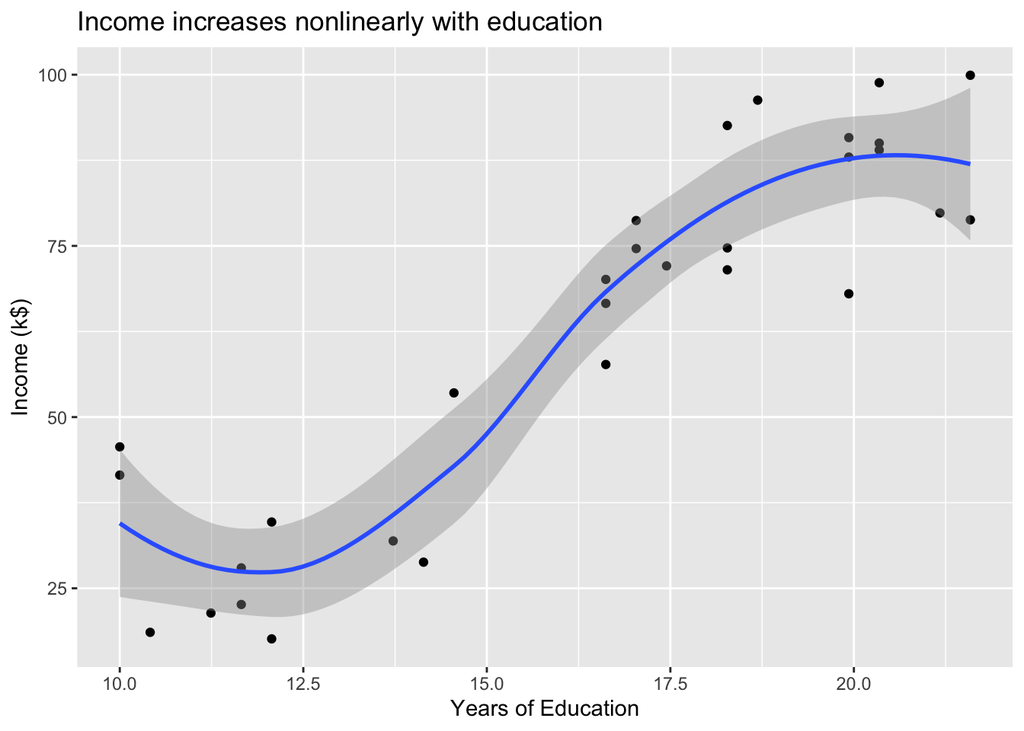

```r
# Plot income ~ Education
income %>%
  ggplot(mapping = aes(x = Education, y = Income)) +
  geom_point() +
  geom_smooth() +
  labs(title = "Income increases nonlinearly with education",
       x = "Years of Education",
       y = "Income (k$)")
```

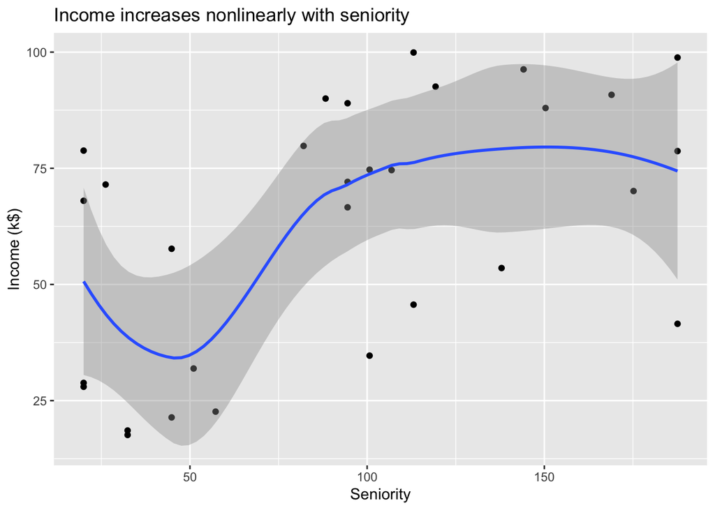

```r
# Plot income ~ Seniority
income %>%
  ggplot(mapping = aes(x = Seniority, y = Income)) +
  geom_point() +
  geom_smooth() +
  labs(title = "Income increases nonlinearly with seniority",
       x = "Seniority",
       y = "Income (k$)")
```

**Python**

```python
# Load the pandas library
import pandas as pd
# Load numpy for array manipulation
import numpy as np
# Load seaborn plotting library
import seaborn as sns
import matplotlib.pyplot as plt

# Set font sizes in plots
sns.set(font_scale = 2)
# Display all columns
pd.set_option('display.max_columns', None)

# Import income2 data
income = pd.read_csv(
  "../data/Income2.csv",
  index_col = 0
  )
income
```

```
    Education   Seniority     Income
1   21.586207  113.103448  99.917173
2   18.275862  119.310345  92.579135
3   12.068966  100.689655  34.678727
4   17.034483  187.586207  78.702806
5   19.931034   20.000000  68.009922
6   18.275862   26.206897  71.504485
7   19.931034  150.344828  87.970467
8   21.172414   82.068966  79.811030
9   20.344828   88.275862  90.006327
10  10.000000  113.103448  45.655529
11  13.724138   51.034483  31.913808
12  18.689655  144.137931  96.282997
13  11.655172   20.000000  27.982505
14  16.620690   94.482759  66.601792
```

[output cut: 16 more lines]

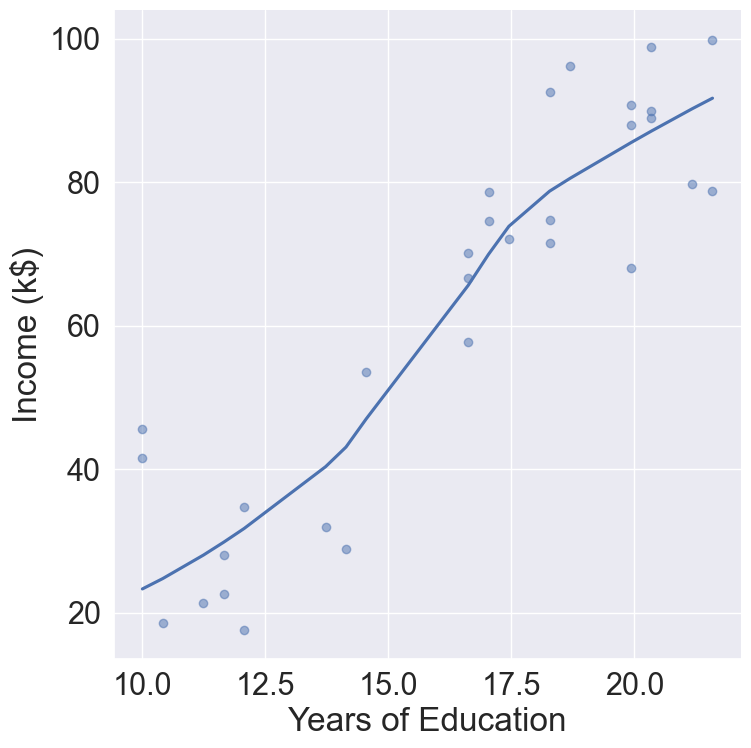

Figure 1: Income increases nonlinearly with education.

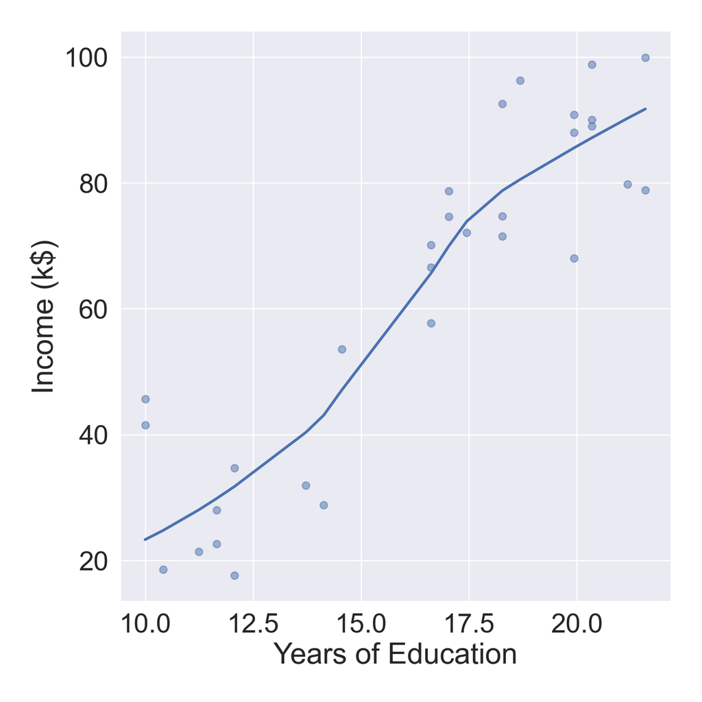

Figure 2: Income increases nonlinearly with education.

```python
# Plot Income ~ Education
sns.lmplot(
  data = income,
  x = "Education",
  y = "Income",
  lowess = True,
  scatter_kws = {'alpha' : 0.5},
  height = 8
  ).set(
  xlabel = 'Years of Education',
  ylabel = 'Income (k$)'
  )
```

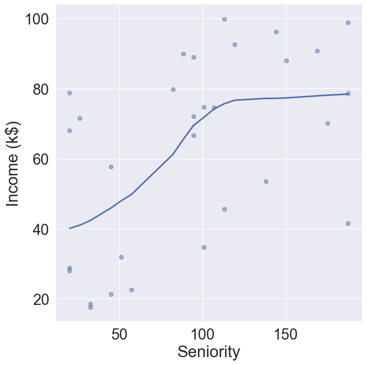

Figure 3: Income increases nonlinearly with seniority.

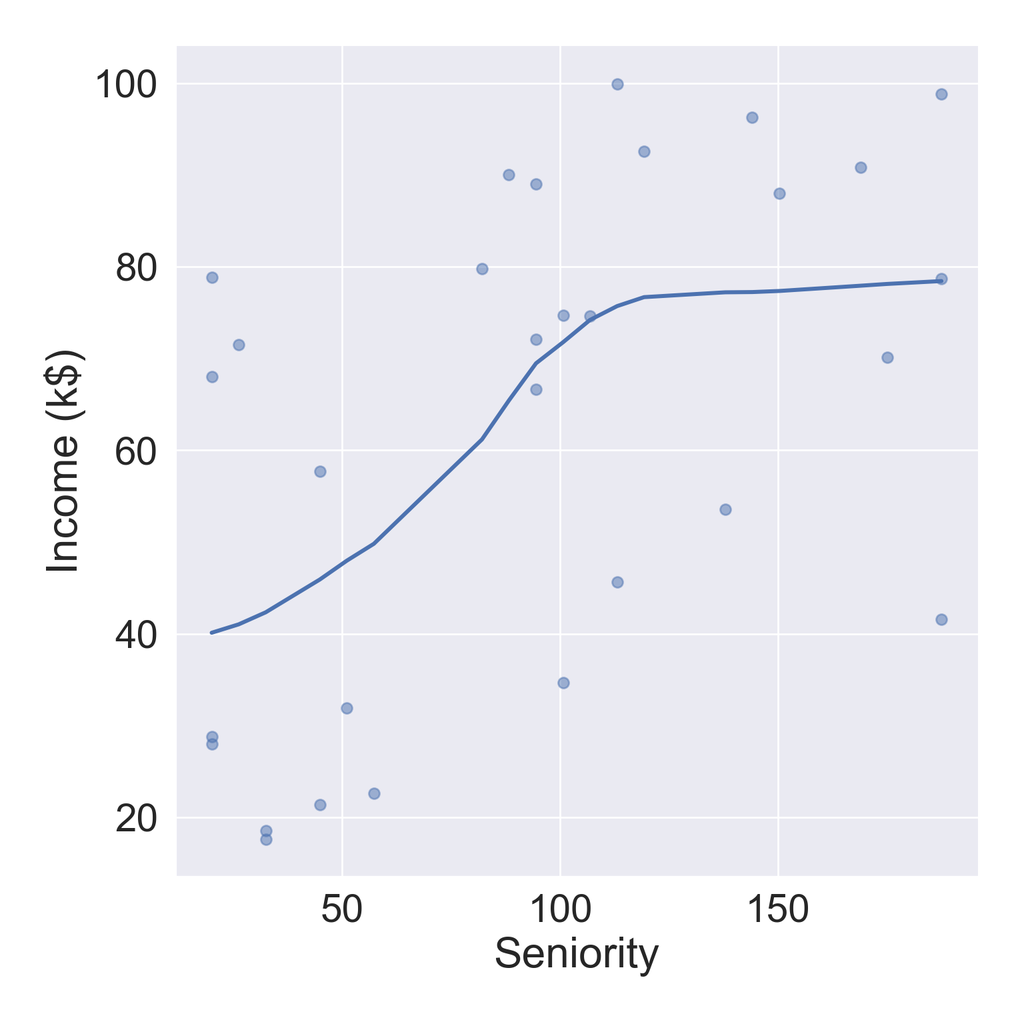

Figure 4: Income increases nonlinearly with seniority.

```python
# Plot Income ~ Seniority
sns.lmplot(
  data = income,
  x = "Seniority",
  y = "Income",
  lowess = True,
  scatter_kws = {'alpha' : 0.5},
  height = 8
  ).set(
  xlabel = 'Seniority',
  ylabel = 'Income (k$)'
  )
```

- Can we predict `Income` using `Years of Education`? Can we predict `Income` using `Seniority`? Perhaps we can do better with a model using both?
  $$\text{Income} \approx f(\text{Education}, \text{Seniority})$$
- $Y$: `Income` is the **response**, or **target**, or **output**, or **outcome**, or **dependent variables** that we wish to predict.
- $X$: `Education` and `Seniority`.
  $$X = \begin{pmatrix} X_1 \\ \vdots \\ X_p \end{pmatrix}$$
  is the vector of **features**, or **inputs**, or **predictors**, or **independent variables**.
- We assume the model
  $$Y = f(X) + \epsilon,
  \tag{1}$$
  where
  - $f$ represents the **systematic information** that $X$ provides about $Y$;
  - The **error term** $\epsilon$ captures measurement errors and other discrepancies.
- In essence, statistical learning refers to a set of approaches for estimating the function $f$.

## 1.2 Why estimate $f$?

- Prediction. With a good estimate $\hat f$, we can predict $Y$ at new points
  $$\hat Y = \hat f (X).$$
- Inference.
  - We can understand which components of $X=(X_1, \ldots, X_p)$ are important in explaining $Y$, and which are irrelevant. For example, `Seniority` and `Years of Education` have a big impact on `Income`, but `Marital Status` typically does not.
  - Depending on the complexity of $f$, we may be able to understand how each component $X_j$ of $X$ affects $Y$. For example, how much extra income will one earn with two more year of education? Does a linear relationship hold?
  - Causal inference. We may infer whether purposedly changing the values of certain predictors will change outcomes. For example, does an advertising campaign increase the sales? Or it’s just seasonal change in sales?

## 1.3 The optimal (but unrealistic) $f$

- It can be shown (HW1) that
  $$f_{\text{opt}} = \operatorname{E}(Y | X)$$
  minimizes the mean-squared prediction error
  $$\operatorname{E}[Y - f(X)]^2,$$
  where the expectations averages over variations in both $X$ and $Y$.
- However we almost never know the conditional distribution of $Y$ given $X$. In practice, we use various learning methods to estimate $f$.

## 1.4 Reducible and irreducible errors

- Assuming $\hat f$ and $X$ are fixed, then

$$\begin{eqnarray*}
\operatorname{E}(Y - \hat Y)^2 &=& \operatorname{E} [f(X) + \epsilon - \hat f(X)]^2 \\
&=& \operatorname{E} \underbrace{[f(X) - \hat f(X)]^2}_\text{Reducible} + \underbrace{\operatorname{Var}(\epsilon)}_\text{Irreducible}.
\end{eqnarray*}$$

- Statistical learning techniques may yield better $\hat f$, thus decreasing the reducible errors.
- Even if we knew the truth $f$, we would still make errors in prediction due to the irreducible error.

## 1.5 How to estimate $f$?

Our goal is to apply a statistical learning method to find a function $\hat f$ such that $Y \approx \hat f(X)$.

### 1.5.1 Parametric or structured model

- Step 1. We make an assumption about the functional form, or shape, of $f$.

  For example, one may assume that $f$ is linear in $X$:
  $$f(X) = \beta_0 + \beta_1 X_1 + \cdots \beta_p X_p.$$
- Step 2. We use the training data $\{(x_1, y_1), \ldots, (x_n, y_n)\}$ to **train** or **fit** the model.

  The most common approach for fitting the linear model is **least squares**. However there are many other possible ways to fit the linear model (to be discussed later).

[figure not shown]

Blue surface is the true $f$

[figure not shown]

Yellow surface is the linear model fit $\hat f$

Figure 5: Linear approximation of $f$.

- Although it is *almost never correct*, a linear model often serves as a good and interpretable approximation to the unknown true function $f$.

### 1.5.2 Non-parametric model

- Non-parametric methods do not make explicit assumptions about the functional form of $f$. Instead they seek an estimate of $f$ that gets as close to the data points as much as possible without being too rough or wiggly.
  - Advantages: better fit.
  - Disadvantage: many more paremeters; need more training samples to accurately estimate $f$.
- **Thin-plate spline** (discussed later) approximates the true $f$ better than the linear model.

[figure not shown]

Blue surface is the true $f$

[figure not shown]

Yellow surface is the thin-plate spline fit $\hat f$

Figure 6: Thin-plate spline fit of $f$.

- We may even fit an extremely flexible spline model such that the fitted model makes no errors on the training data! By doing this, we are in the danger of **overfitting**. Overfit models do not generalize well, which means the prediction accuracy on a separate test data can be very bad.

[figure not shown]

Blue surface is the true $f$

[figure not shown]

Overfitting

Figure 7: Overfitting of $f$.

## 1.6 Some trade-offs

- Prediction accuracy vs interpretability.
  - Linear models are easy to interpret; thin-plate splines are not.
- Good fit vs over-fit or under-fit.
  - How do we know when the fit is just right?
- Parsimony vs black-box.
  - Practitioners often prefer a simpler model involving fewer variables over a black-box predictor involving them all.

[figure not shown]

Figure 8: Trade-off of model flexibility vs interpretability.

## 1.7 Assessing model accuracy

- Given training data $\{(x_1, y_1), \ldots, (x_n, y_n)\}$, we fit a model $\hat f$. We can evaluate the model accuracy on the training data by the **mean squared error**
  $$\operatorname{MSE}_{\text{train}} = \frac 1n \sum_{i=1}^n [y_i - \hat f(x_i)]^2.$$
  The smaller $\operatorname{MSE}_{\text{train}}$, the better model fit.
- However, in most situations, we are not interested in the training MSE. Rather, we are interested in the accuracy of the predictions on previously unseen test data.
  - If we have a separate test set with both predictors and outcomes. Then the task is easy, we choose the learning method that yields the best test MSE
    $$\operatorname{MSE}_{\text{test}} = \frac{1}{n_{\text{test}}} \sum_{i=1}^{n_{\text{test}}} [y_i - \hat f(x_i)]^2.$$
  - In many applications, we don’t have a separate test set. Is this a good idea to choose the learning method with smallest training MSE?

[figure not shown]

Figure 9: Black curve is truth. Red curve on right is the test MSE, grey curve is the training MSE. Orange, blue and green curves/squares correspond to fits of different flexibility.

[figure not shown]

Figure 10: Here the truth is smoother, so the smoother fit and linear model do really well.

[figure not shown]

Figure 11: Here the truth is wiggly and the noise is low, so the more flexible fits do the best.

- As the previous three examples illustrate, the flexibility level corresponding to the model with the minimal test MSE can vary considerably among data sets.
- Later we will discuss the **cross-validation** strategy to estimate test MSE using only the training data.

## 1.8 Bias-variance trade-off

- The U-shaped observed in the test MSE curves (Figure 911) reflects the **bias-variance** trade-off.
- Let $(x_0, y_0)$ be a test observation. Under the model Equation 1, the **expected prediction error (EPE)** at $x_0$, or the **test error**, or **generalization error**, can be decomposed as (HW1)
  $$\operatorname{E}[y_0 - \hat f(x_0)]^2 = \underbrace{\operatorname{Var}(\hat f(x_0)) + [\operatorname{Bias}(\hat f(x_0))]^2}_{\text{MSE of } \hat f(x_0) \text{ for estimating } f(x_0)} + \underbrace{\operatorname{Var}(\epsilon)}_{\text{irreducible}},$$
  where
  - $\operatorname{Bias}(\hat f(x_0)) = \operatorname{E}[\hat f(x_0)] - f(x_0)$;
  - the expectation averages over the variability in $y_0$ and $\hat f$ (function of training data).
- Typically as the flexibility of $\hat f$ increases, its variance increases and its bias decreases.

[figure not shown]

Figure 12: Bias-variance trade-off.

## 1.9 Classical regime vs modern regime

- Above U-shaped test MSE curves are in the so-called **classical regime** where the number of features (or the degree of freedom) is less than the training samples.

  In the **modern regime**, where the number of features (or the degree of freedom) can be order of magnitude larger than the training samples (recall that ChatGPT3 model has 175 billion parameters!), the **double descent** phenomenon is observed and being actively studied. See
  - [paper](https://epubs.siam.org/doi/pdf/10.1137/20M1336072)
  - [Linear regression with minimum-norm interpolators](https://hastie.su.domains/Papers/21-AOS2133.pdf)
  - [Benign overfitting in linear regression](https://www.pnas.org/doi/10.1073/pnas.1907378117)
  - [Double descent: Where bigger models and more data hurt](https://openreview.net/forum?id=B1g5sA4twr)

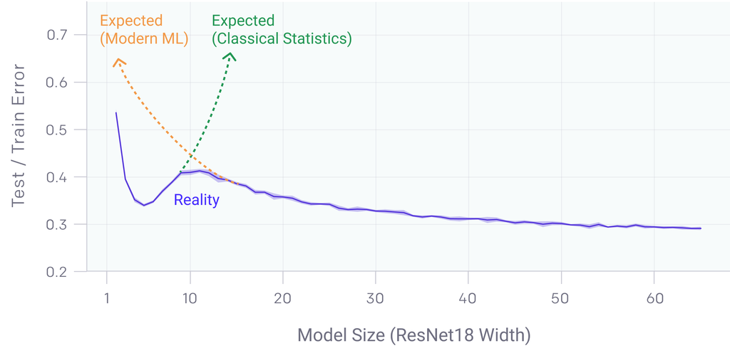

Figure 13: Double descent phenomenon ([OpenAI Blog](https://openai.com/blog/deep-double-descent/)).

## 1.10 Classification problems

- When the outcome $Y$ is discrete, for example, email is one of $\mathcal{C}=${`spam`, `ham`} (`ham`=good email), handwritten digit is one of $\mathcal{C} = \{0,1,\ldots,9\}$.
- Our goals are to
  - build a classifier $f(X)$ that assigns a class label from $\mathcal{C}$ to a future unlabeled observation $X$;
  - assess the uncertainty in each classification;
  - understand the roles of the different predictors among $X=(X_1,\ldots,X_p)$.
- To evaluate the performance of classification algorithms, the **training error rate** is
  $$\frac 1n \sum_{i=1}^n I(y_i \ne \hat y_i),$$
  where $\hat y_i = \hat f(x_i)$ is the predicted class label for the $i$th observation using $\hat f$.
- As in the regression setting, we are most interested in the **test error rate** associated with a set of test observations
  $$\frac{1}{n_{\text{test}}} \sum_{i=1}^{n_{\text{test}}} I(y_i \ne \hat y_i).$$
- Suppose $\mathcal{C}=\{1,2,\ldots,K\}$, the **Bayes classifier** assigns a test observation with predictor vector $x_0$ to the class $j \in \mathcal{C}$ for which
  $$\operatorname{Pr}(Y=j \mid X = x_0)$$
  is largest.

  In a two-class problem $K=2$, the Bayes classifier assigns a test case to class 1 if $\operatorname{Pr}(Y=1 \mid X = x_0) > 0.5$, and to class 2 otherwise.
- The Bayes classifier produces the **lowest** possible test error rate, called the **Bayes error rate**
  $$1 - \max_j \operatorname{Pr}(Y=j \mid X = x_0)$$
  at $X=x_0$. The **overall Bayes error** is given by
  $$1 - \operatorname{E} [\max_j \operatorname{Pr}(Y=j \mid X)],$$
  where the expectation averages over all possible values of $X$.
- Unfortunately, for real data, we don’t know the conditional distribution of $Y$ given $X$, and computing the Bayes classifier is impossible.
- Various learning algorithms attempt to estimate the conditional distribution of $Y$ given $X$, and then classify a given observation to the class with the highest estimated probability.
- One simple classifier is the **$K$-nearest neighbor (KNN)** classifier. Given a positive integer $K$ and a test observation $x_0$, the KNN classifier first identifies the $K$ points in the training data that are closest to $x_0$, represented by $\mathcal{N}_0$. It then estimates the conditional probability by
  $$\operatorname{Pr}(Y=j \mid X = x_0) = \frac{1}{K} \sum_{i \in \mathcal{N}_0} I(y_i = j)$$
  and then classifies the test observation $x_0$ to the class with the largest probability.

[figure not shown]

Figure 14: Black curve is the KNN decision boundary using $K=10$. The purple dashed line is the Bayes decision boundary.

- Smaller $K$ yields more flexible classification rule.

[figure not shown]

Figure 15: Left panel: KNN with $K=1$. Right panel: KNN with $K=100$.

- Bias-variance trade-off of KNN.

[figure not shown]

Figure 16: KNN with $K \approx 10$ achieves the Bayes error rate (black dashed line).